# Введение в Linux - первый этап внешнего курса

Презентация

Виноградова М. А.

Российский университет дружбы народов, Москва, Россия

15 мая 2025

# Информация

## Докладчик

- Виноградова Мария Андреевна
- Студентка (студ. билет 1132240691)
- группа НПИбд-01-24
- Российский университет дружбы народов
- 1132240691@pfur.ru
- https://github.com/mavinogradova/study_2024-2025_os-intro

# Цель работы

Познакомиться с операционной системой Linux и её базовыми возможностями.

# Выполнение первого этапа внешнего курса

## 1. Установить себе в систему плеер VLC. Далее нужно было запустить, откройть Help → About (или Shift+F1) и написать ниже первую фамилию из вкладки Authors

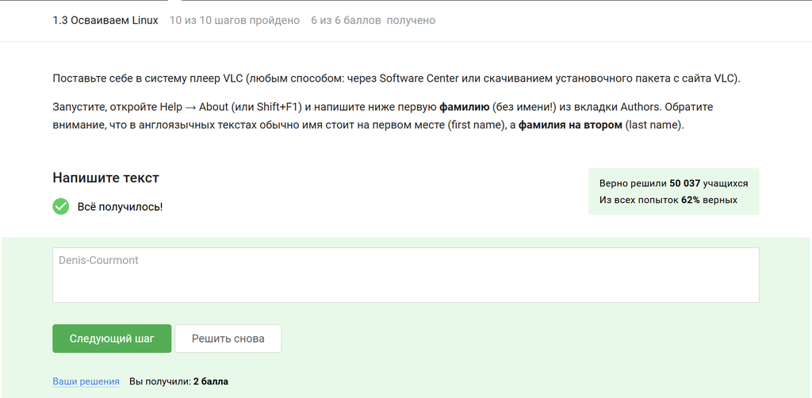

Ознакамливаемся с заданием

## Далее через консоль был скачан плеер и выполнены необходимые действия для выполнения задания

[figure not shown]

Заходим в плеер и находим нужную информацию

## 2. Через команду man узнать справку о команде ls и выяснить какие эквивалентные команды есть в предлагаемом списке

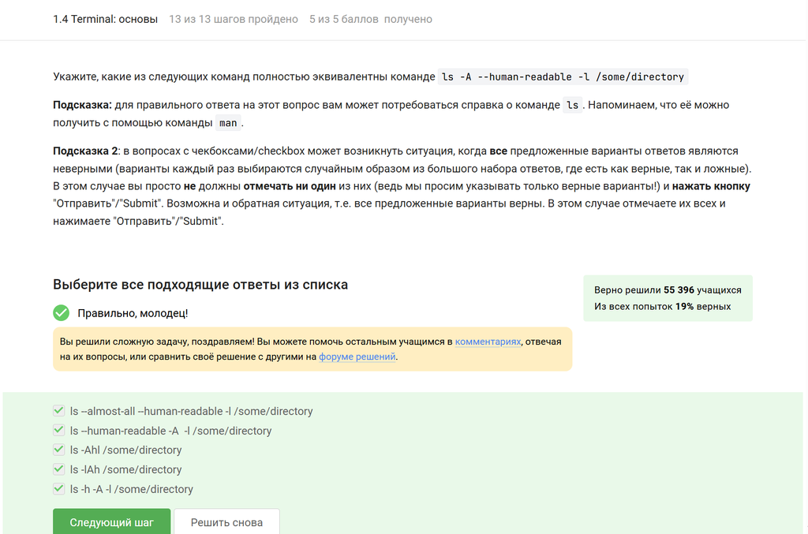

Ознакамливаемся с заданием

## Далее через консоль была открыта справка о команде ls, мы ознакомились с информацией по ней и смотли выполнить поставленную задачу

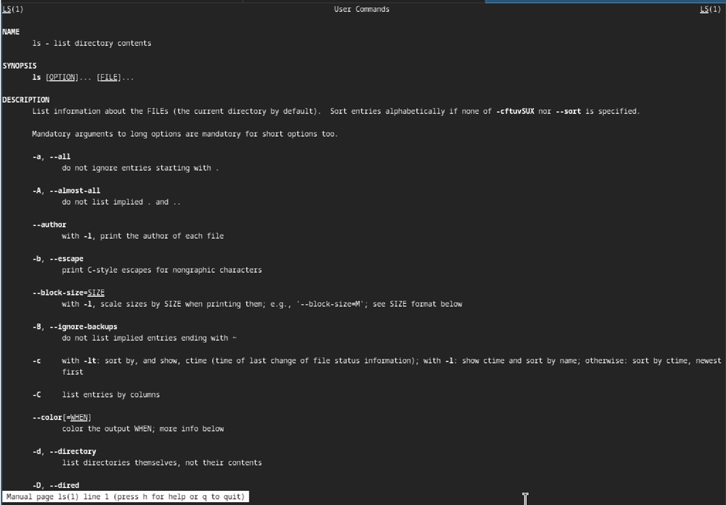

Изучаем информацию и выполняем задание

## 3. Что произойдет если ввести в терминал команды firefox exit если перед вводом данных команд одноименный браузер закрыт

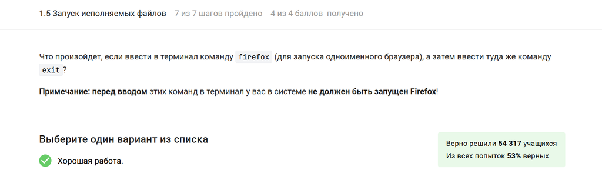

Ознакамливаемся с заданием

## 4. Скачать файл с программой сделать его исполняемым а затем запустить его и посмотреть что он выведет

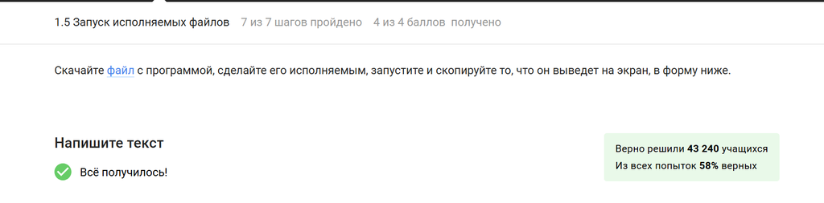

Ознакамливаемся с заданием

## Скачиваем файл, делаем его исполняемым с помощью команды и затем запускаем, чтоюы узнать что он выводит

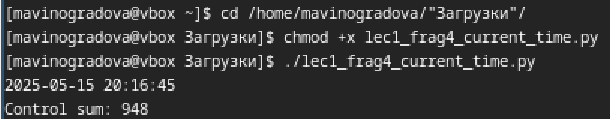

Скачиваем файл и запускаем его с правами на исполнение

## .5 Выянить куда по умолчанию выводится поток ошибок программы, запущенной в терминале

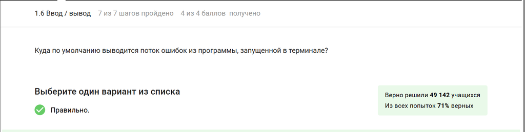

Ознакамливаемся с заданием

## Для проверки запускаем в терменале неправильную команду и узнаем ответ на задание

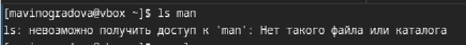

Вводим в терминал заведомо ошибочную команду

## 6. Узнать в каком файле окажется скачанная с помощью предоставленных команд картинка

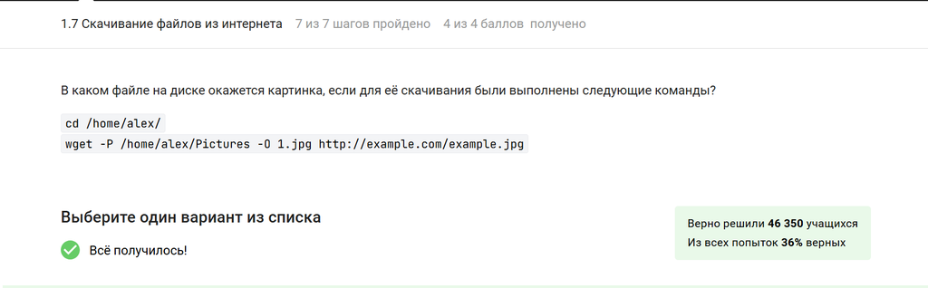

Ознакамливаемся с заданием

## Вводим предоставленные команды и смотрим куда загрузился файл

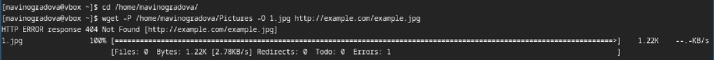

Скачиваем картинку и смотрим её расположение

## 7. Указать опцию команде wget, чтобы она не выводила никаких сообщений на экран,воспользовавшись для этого командой man

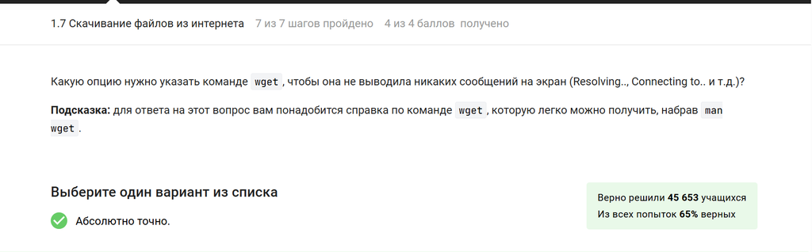

Ознакамливаемся с заданием

## Вводим в терминал команду man wget и узнаем информацию по команде

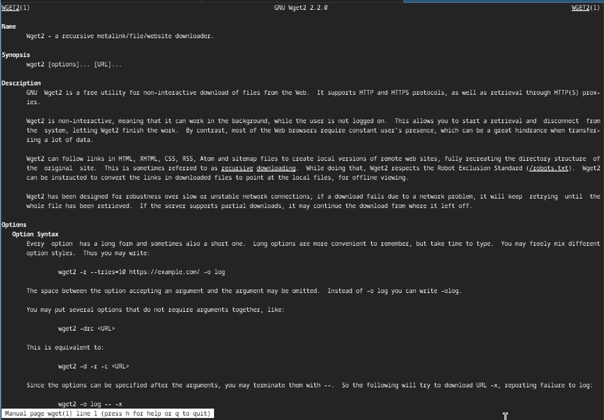

Смотрим справку команды

## 8. Узнать какие файлы будут скачаны на компьютер, если запустить wget -r -l 1 -A jpg и передать в качестве аргумента ссылку на эту web-страницу

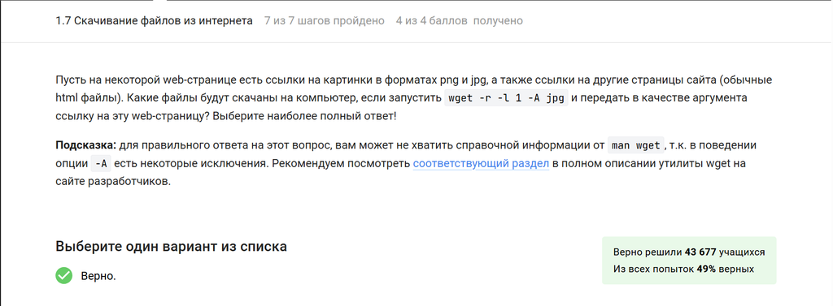

Ознакамливаемся с заданием

## Открываем предоставленную в задании справочную информацию по команде и с помощью этих данных выполнем задание

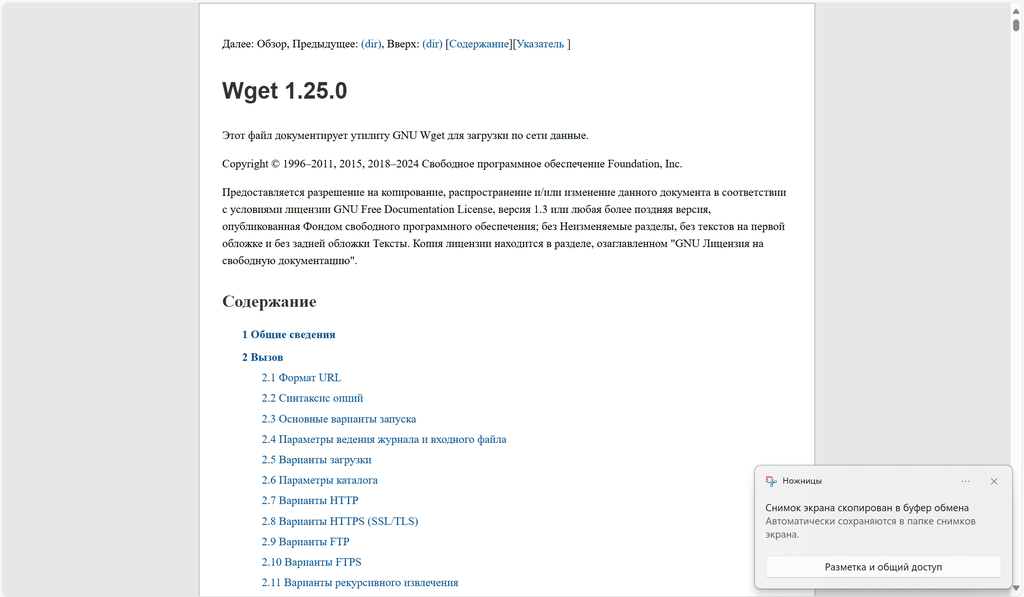

Смотрим справочную информацию команды

## 9. Узнать какая маска команды find НЕ найдет файл Alexey.jpeg

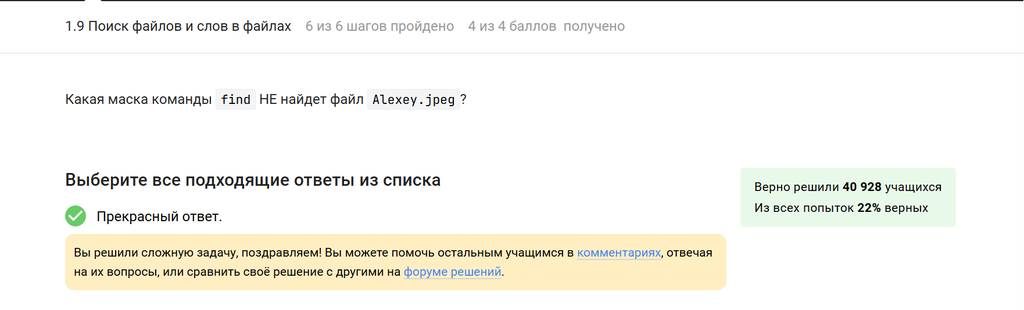

Ознакамливаемся с заданием

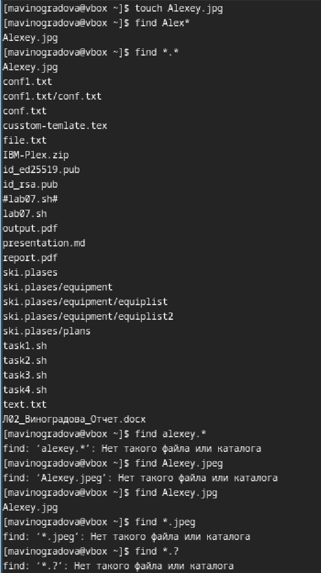

Создаем файл и поочередно проверяем команду с различными масками

## 10. Узнать какие строки выводит на экран команда grep “world” text.txt. из предоставленного файла

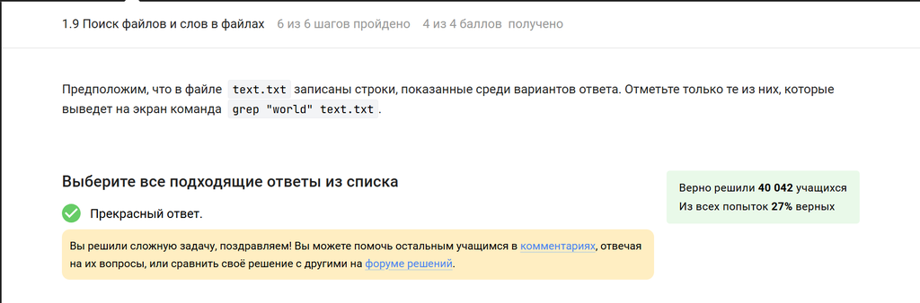

Ознакамливаемся с заданием

## Для этого создаем файл со всеми предоставленными в вариантах ответа строками и вводим в терминал команду тем самым проверяя её вывод

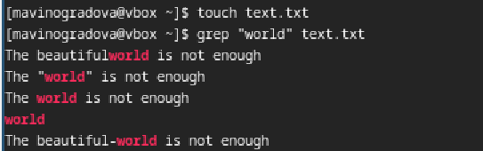

Создаем файл и проверяем вывод команды

## 11. Скачать архив с произведениями и сгенерировать файл в который нужно перенаправить все сстрочки из скачанного архива содержащие “love”

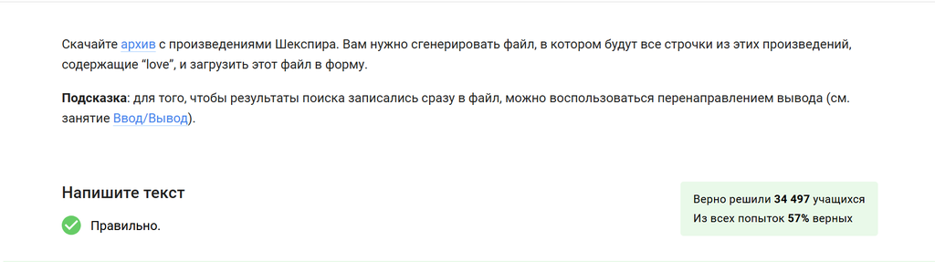

Ознакамливаемся с заданием

## Скачиваем предоставленный архив, распаковываем его и с помощью команды перенаправляем все необходимые строчки в отдельно созданный файл.

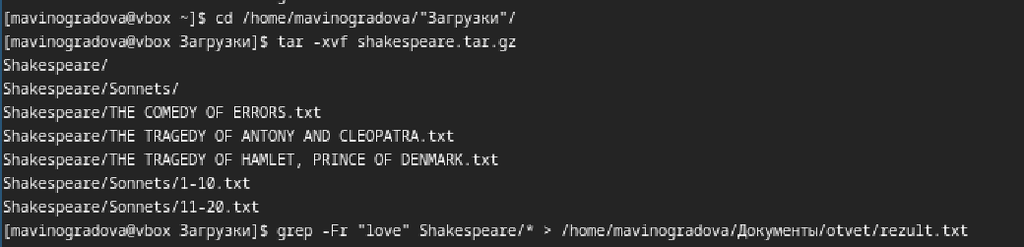

Скачиваем архив и перенаправляем необходимые строчки в другой файл

## Дальше нам нужно убедится что строчки были перенаправленны, для этого открываем сгенерированный ранее файл и смотрим на его содержимое

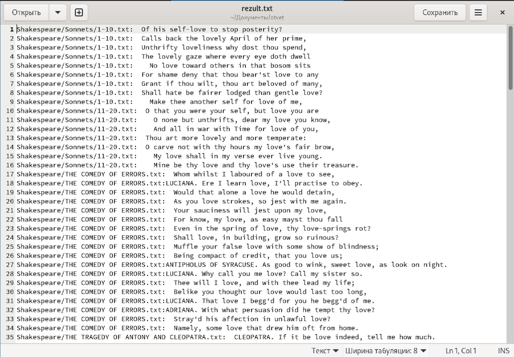

Открываем файл и проверяем содержимое

# Выводы

Пройден начальный этап знакомства с Linux, включающий установку ОС, изучение графического интерфейса и базовых команд терминала. Получены фундаментальные навыки работы в Linux-среде, заложена основа для дальнейшего освоения командной строки.